# Multiple Choice Survey Data Clean

2022-05-04

There are lots of great survey tools available, but almost all of them have a completely data export format and they’re often not that… great. This is particularly true when surveys contain multiple choice questions, the data comes in lots of different untidy formats.

This blogpost is going to demonstrate how we would use tidy data principles and the tidyverse to wrangle data from a variety of different survey tools. The data was initially gathered by me tweeting a link to the exact same survey in Google Forms, Qualtrics and Survey Monkey.

> I'm writing a blogpost on tidying multiple choice survey questions with {tidyr}.  
> Could you help by completing these <1min surveys?https://t.co/n4o50idCCqhttps://t.co/ouqi3k7EZLhttps://t.co/UtsRxsJ8HR [pic.twitter.com/Y6FzT37CUH](https://t.co/Y6FzT37CUH)

> — Charlotte 👩‍💻 (@charliejhadley) [April 28, 2022](https://twitter.com/charliejhadley/status/1519696924328214528?ref_src=twsrc%5Etfw)

The survey contained just one question that looks like this:

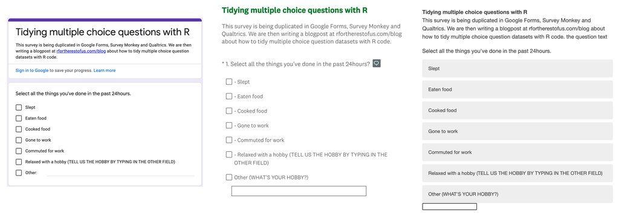

# Google Forms

Google Forms is the survey tool we usually choose as the forms look good and we can read the responses into R via the excellent [{googlesheets4}](https://googlesheets4.tidyverse.org/) package. To make things simpler, you can [download the results as an Excel file](https://github.com/rfortherestofus/rforus_tidying-survey-data/raw/main/data/google-forms-data.xlsx).

VIDEO: https://muse.ai/v/mbbdvf3

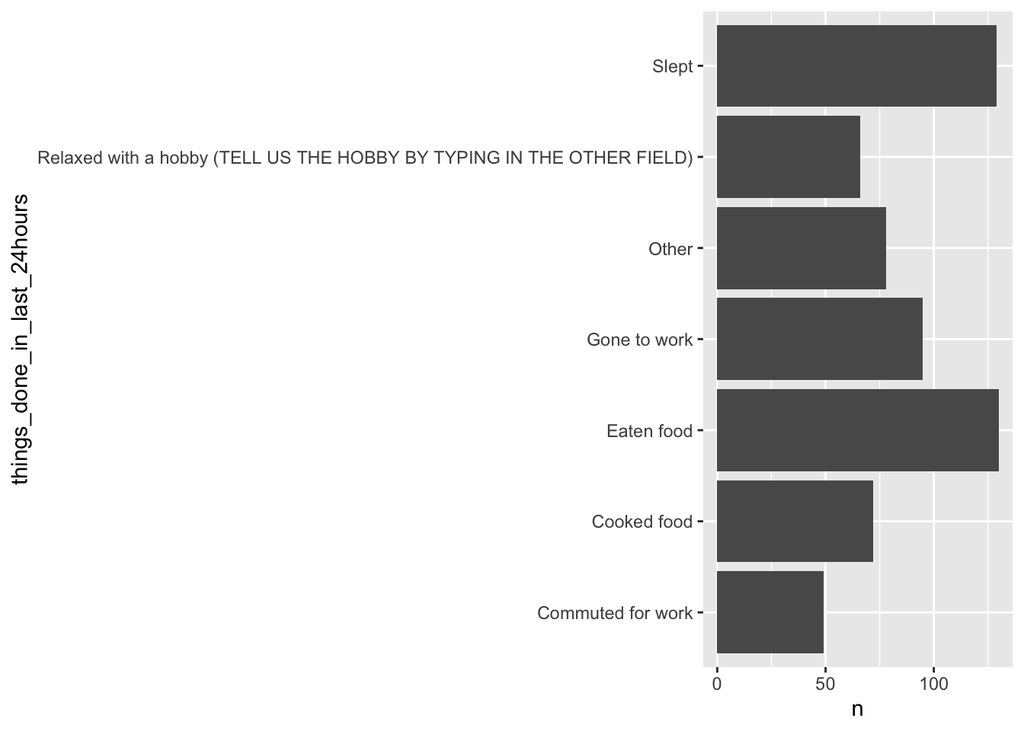

# Survey Monkey

Survey Monkey no longer has a free tier that allows you to download data from the service. There is an experimental package [{surveymonkey}](https://github.com/mattroumaya/surveymonkey) for directly downloading data from your account - but I haven’t experimented with it.

The export format of Survey Monkey splits headers across multiple rows, which the {readxl} package on its own isn’t designed to deal with. However, the awesome [{unheadr}](https://github.com/luisDVA/unheadr) package allows us to mash together column names across multiple rows.

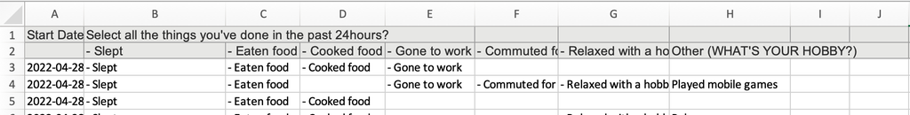

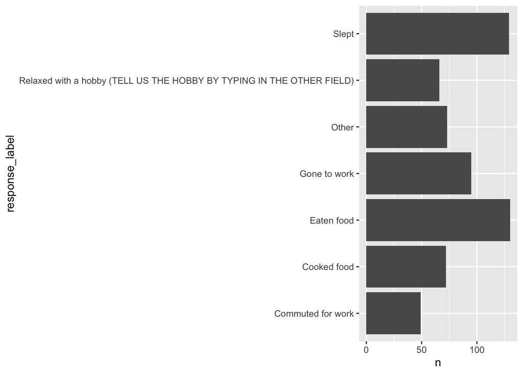

# Qualtrics

Qualtrics does have a free tier allowing us to download data. There’s also a great package called [{qualtRics}](https://docs.ropensci.org/qualtRics/) for programmatically downloading survey data from the platform.

I actually really appreciate the data format that Qualtrics uses, each question has two columns: one for the fixed responses and the other column contains write in values. As I demonstrate in the video below we can use separate_rows() to convert observations into a long, tidy dataset.

VIDEO: https://muse.ai/v/rWYr23B

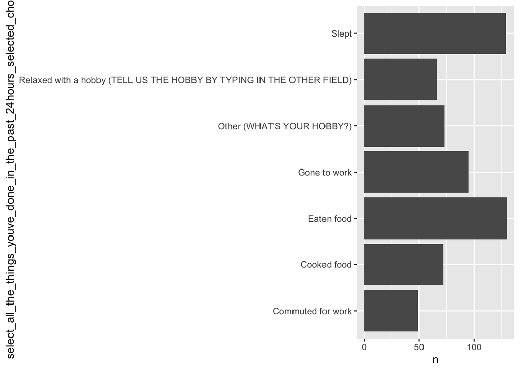